# Health and Economic Impact From Severe Weather in the US

## Synopsis

Severe weather such as stroms and flood can significantlt affect both population health and economics in the US. Understanding the consequences caused by such weather can provide us a helpful tool for future disaster prevention and rebuild. This analysis takes advantage of the U.S. National Oceanic and Atmospheric Administration’s (NOAA) storm database, Analysis shows that tornado on average caused the most death and injuries in the past 60 years in the US. On the other hand, the weather type responsiblle for the most property loss is flood, and the weather type responsible for the most crop loss is drought.

## Data processing

### 1.Read in NOAA weather data

```r
weather_data<- read.csv('repdata-data-StormData.csv.bz2')
weather_data<- tbl_df(weather_data)
```

### 2.find the most leathal weather type

The health related data in stored in column “FATALITIES” and “INJURIES”, indicating death and injuries, respectively. group and summarise the data by “EVTYPE”(event type) to get the total death and injuries by each weather type.

```r
health_related_data<- head(weather_data%>%
                  select(c(EVTYPE,FATALITIES,INJURIES))%>%
                  group_by(EVTYPE)%>%
                  summarise(death_injuried=sum(FATALITIES,INJURIES))%>%
                  arrange(desc(death_injuried)),10)
health_related_data
```

```
## Source: local data frame [10 x 2]
##
##               EVTYPE death_injuried
##               (fctr)          (dbl)
## 1            TORNADO          96979
## 2     EXCESSIVE HEAT           8428
## 3          TSTM WIND           7461
## 4              FLOOD           7259
## 5          LIGHTNING           6046
## 6               HEAT           3037
## 7        FLASH FLOOD           2755
## 8          ICE STORM           2064
## 9  THUNDERSTORM WIND           1621
## 10      WINTER STORM           1527
```

### 3.find the weather with most economic impact

The economic damage is categorized as “PROPDMG” and “CROPDMG”, indicating “property damage” and “crop damage” respectively. variable “PROPDMGEXP”" and “CROPDMGEXP” are used to determine the damage level(in hundreds,thousands,millions or billions).

```r
unique(weather_data[,'PROPDMGEXP']) #get levels of PROPDMGEXP
```

```
## Source: local data frame [19 x 1]
##
##    PROPDMGEXP
##        (fctr)
## 1           K
## 2           M
## 3
## 4           B
## 5           m
## 6           +
## 7           0
## 8           5
## 9           6
## 10          ?
## 11          4
## 12          2
## 13          3
## 14          h
## 15          7
## 16          H
## 17          -
## 18          1
## 19          8
```

```r
unique(weather_data[,'CROPDMGEXP']) #get levels of CROPDMGEXP
```

```
## Source: local data frame [9 x 1]
##
##   CROPDMGEXP
##       (fctr)
## 1
## 2          M
## 3          K
## 4          m
## 5          B
## 6          ?
## 7          0
## 8          k
## 9          2
```

```r
# calculate the damages based on PROPDMGEXP and CROPDMGEXP. then group and summarise the total economic loss caused by different weather events.
economic_related_data<- weather_data%>%
                  select(c(EVTYPE,PROPDMG,PROPDMGEXP,CROPDMG,CROPDMGEXP))%>%
                  mutate(PROPDMGEXP=as.character(PROPDMGEXP),CROPDMGEXP=as.character(CROPDMGEXP))%>%
                  mutate(proerty_damage=ifelse(!is.na(as.numeric(PROPDMGEXP)),PROPDMG*(10^as.numeric(PROPDMGEXP)),
                                        ifelse(PROPDMGEXP%in%c('H','h'),PROPDMG*100,
                                        ifelse(PROPDMGEXP%in%c('K','k'),PROPDMG*1e+03,
                                        ifelse(PROPDMGEXP%in%c('M','m'),PROPDMG*1e+06,
                                        ifelse(PROPDMGEXP%in%c('B','b'),PROPDMG*1e+09,0))))),
                         crop_damage=ifelse(!is.na(as.numeric(CROPDMGEXP)),CROPDMG*(10^as.numeric(CROPDMGEXP)),
                                     ifelse(CROPDMGEXP%in%c('K','k'),CROPDMG*1e+03,
                                     ifelse(CROPDMGEXP%in%c('M','m'),CROPDMG*1e+06,
                                     ifelse(CROPDMGEXP%in%c('B','b'),CROPDMG*1e+09,0)))))%>%
                  select(EVTYPE,proerty_damage,crop_damage)%>%
                  group_by(EVTYPE)%>%
                  summarise(proerty_damage=sum(proerty_damage),crop_damage=sum(crop_damage))
property_related_data<- head(economic_related_data%>%
                        select(EVTYPE,proerty_damage)%>%
                        arrange(desc(proerty_damage)),10)
crop_related_data<- head(economic_related_data%>%
                        select(EVTYPE,crop_damage)%>%
                        arrange(desc(crop_damage)),10)
```

# Results

plot data from both health and economic related data.

## 1.data presentation of health related data

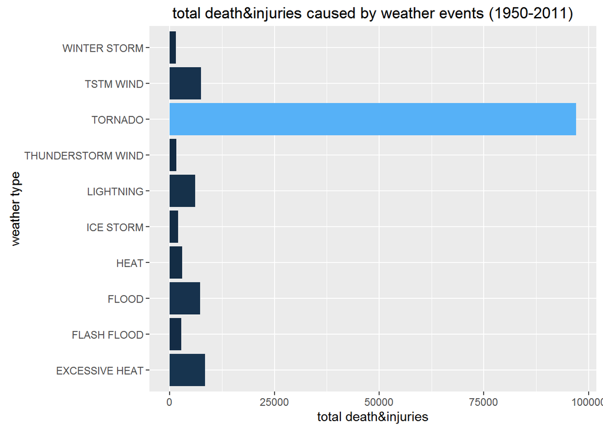

```r
p<-ggplot(health_related_data,aes(as.character(EVTYPE),death_injuried,fill=death_injuried))
p+geom_bar(stat="identity")+coord_flip()+theme(legend.position="none")+
  ylab('total death&injuries')+
  xlab('weather type')+
  ggtitle('total death&injuries caused by weather events (1950-2011)')
```

The weather type responsible for the most death and injuries is the US for the past 60 years is *TORNADO*.

## 2.data presentation of property realted data

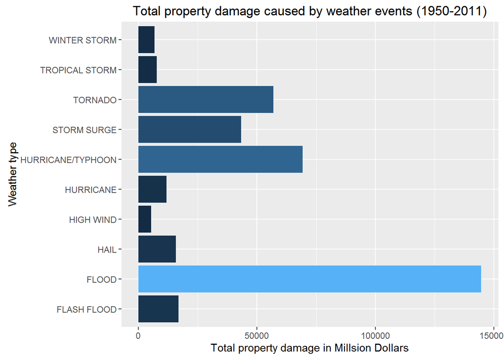

```r
p<-ggplot(property_related_data,aes(as.character(EVTYPE),proerty_damage/10^6,fill=proerty_damage))
p+geom_bar(stat="identity")+
  coord_flip()+
  theme(legend.position="none")+
  ylab('Total property damage in Millsion Dollars')+
  xlab('Weather type')+
  ggtitle('Total property damage caused by weather events (1950-2011)')
```

The weather type responsible for the most property damage is *FLOOD*

## 3.data presentation of crop realted data

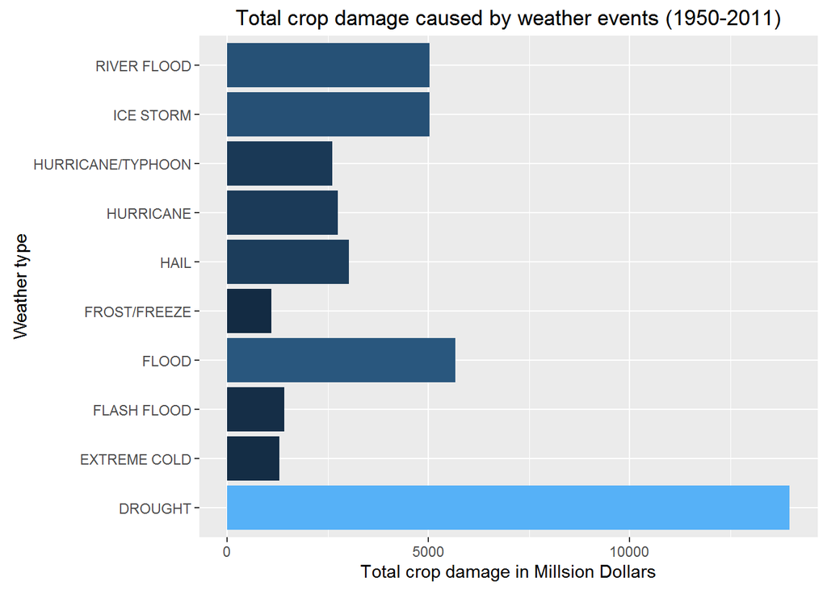

```r
p<-ggplot(crop_related_data,aes(as.character(EVTYPE),crop_damage/10^6,fill=crop_damage))
p+geom_bar(stat="identity")+
  coord_flip()+
  theme(legend.position="none")+
  ylab('Total crop damage in Millsion Dollars')+
  xlab('Weather type')+
  ggtitle('Total crop damage caused by weather events (1950-2011)')
```

The weather type responsible for the most crop damage is *DROUGHT*